# Predicting Chronic Kidney Disease from Routine Clinical Measurements

Authors

June Lynn

Richard von Celsing

Carmen Zhang

Graham Greene

Published

November 26, 2026

## Summary

In this project we build a classification model using a logistic regression algorithm which uses patient tests and information to predict whether a patient has chronic kidney disease. In practice, if a patient is determined to likely have chronic kidney disease based on the model, a clinician can evaluate them and do further testing. On a held-out test set, our final classifier had a recall of 0.92 and an F2 score (beta = 2) of 0.88. Of the 63 patients in the test set with chronic kidney disease, the model predicted 58 of them correctly (true positives) and 5 incorrectly (false negatives), giving a recall of 0.92. The decision threshold of the model was tuned explicitly to minimize false negative predictions because they are most harmful in this context where patients with chronic kidney disease who are classified incorrectly could result in delayed treatment and avoidable adverse health outcomes. It is important to note that of the 37 healthy patients in the test set, 21 of them were flagged as having chronic kidney disease. This high false positive rate would likely not be acceptable in a clinical setting due to the incurred costs of having to run extra tests on a large number of patients who are actually healthy. Before deployment in a clinical setting, we therefore recommend improving the model’s precision through further research efforts while ensuring the recall remains at a similarly high level.

## Introduction

Chronic kidney disease (CKD) is a long-term condition in which the kidneys gradually lose their ability to filter waste and excess fluid from the blood. It is usually diagnosed with laboratory tests, most often by estimating how well the kidneys filter blood from the level of serum creatinine, a waste product that builds up when the kidneys are not working well (Kovesdy 2022). CKD is common worldwide. In 2017, there were an estimated 697.5 million cases of CKD, a global prevalence of 9.1%, and CKD caused 1.2 million deaths (GBD Chronic Kidney Disease Collaboration 2020). Between 1990 and 2017, the global all-age death rate from CKD increased by 41.5% (GBD Chronic Kidney Disease Collaboration 2020). The disease is more common in people with diabetes and high blood pressure, and it places an especially large burden on low- and middle-income countries, which are the least equipped to deal with its consequences (Kovesdy 2022).

Detecting CKD early is important but difficult. CKD usually has no obvious symptoms in its early stages, so it may not be detected until the kidneys have already lost a substantial part of their function (Qin et al. 2020). Early detection allows patients to receive treatment that can slow the progression of the disease (Qin et al. 2020), which may help them avoid or delay kidney failure, when dialysis or a kidney transplant becomes necessary. Many of the measurements that are relevant to kidney health, such as blood pressure and common blood and urine tests, are inexpensive and are already collected during routine care. If a machine learning model can use these measurements to accurately identify patients who are likely to have CKD, it could help clinicians decide which patients need further testing. This could be especially useful in settings where access to kidney specialists is limited.

In this project, we ask the following question: **Can we predict whether a patient has chronic kidney disease using their age, blood pressure, blood and urine test results, and medical history?** Once the data is explored, a smaller subset of these features is used for prediction.

To answer this question, we use the Chronic Kidney Disease data set from the UCI Machine Learning Repository (Rubini, Soundarapandian, and Eswaran 2015). The data were collected from patients at a hospital in Tamil Nadu, India, over a period of nearly two months. Each row in the data set represents one patient, and there are 400 patients in total. Each patient is described by 24 features, which fall into four groups:

- **Demographics and vital signs:** age and blood pressure.
- **Urine tests:** specific gravity, albumin, sugar, red blood cells, pus cells, pus cell clumps, and bacteria.
- **Blood tests:** random blood glucose, blood urea, serum creatinine, sodium, potassium, hemoglobin, packed cell volume, white blood cell count, and red blood cell count.
- **Medical history and symptoms:** whether the patient has hypertension, diabetes mellitus, coronary artery disease, pedal edema (swelling of the feet), or anemia, and whether their appetite is good or poor.

Of these features, 11 are numeric and 13 are categorical. Many values are missing; for example, some patients do not have results for every blood test. The data set is shared under a Creative Commons Attribution 4.0 International (CC BY 4.0) license.

The target variable we want to predict is the diagnosis of each patient: either CKD or not CKD. The data set contains 250 patients with CKD and 150 patients without CKD. We treat CKD as the positive class, because correctly identifying patients who have the disease is the main goal of a screening tool. Since every patient has a recorded diagnosis along with clinical measurements, this data set allows us to train and evaluate a classification model that answers our question.

## Methods

```python
import subprocess
import sys
from pathlib import Path

import altair as alt
alt.renderers.enable("png")
import matplotlib.pyplot as plt
import pandas as pd
import seaborn as sns
from sklearn.model_selection import train_test_split
```

### Data

We downloaded the data from the UCI Machine Learning Repository (Rubini, Soundarapandian, and Eswaran 2015) using a script (`scripts/download_data.py`) that saves it as-is to `data/raw/`. The report runs this script when it renders, so all results come straight from the original source.

```python
subprocess.run(
    [sys.executable, "scripts/download_data.py"],
    cwd="..", check=True, capture_output=True,
)
ckd = pd.read_csv("../data/raw/ckd_raw.csv")
```

Two text columns contained stray tab characters: one diabetes value was recorded as a tab followed by “no” and two diagnoses were recorded as “ckd” followed by a tab. We removed leading and trailing whitespace from every text column.

```python
text_cols = ckd.select_dtypes(exclude="number").columns
ckd[text_cols] = ckd[text_cols].apply(lambda s: s.str.strip())
```

### Train/test split

We split the data into a training set (75%, 300 patients) and a test set (25%, 100 patients). The split was stratified by diagnosis so both sets keep the original proportion of patients with CKD (62.5%). All exploratory analysis and feature selection below uses the training set only; the test set is set aside for the final evaluation of the model.

```python
train_df, test_df = train_test_split(
    ckd, test_size=0.25, random_state=522, stratify=ckd["class"]
)

labels = {
    "age": "Age (years)", "bp": "Blood pressure (mm Hg)",
    "sg": "Specific gravity", "al": "Albumin (0-5)", "su": "Sugar (0-5)",
    "rbc": "Red blood cells", "pc": "Pus cells", "pcc": "Pus cell clumps",
    "ba": "Bacteria", "bgr": "Blood glucose random (mg/dL)",
    "bu": "Blood urea (mg/dL)", "sc": "Serum creatinine (mg/dL)",
    "sod": "Sodium (mEq/L)", "pot": "Potassium (mEq/L)",
    "hemo": "Hemoglobin (g/dL)", "pcv": "Packed cell volume (%)",
    "wbcc": "White blood cell count (cells/cumm)",
    "rbcc": "Red blood cell count (millions/cmm)",
    "htn": "Hypertension", "dm": "Diabetes mellitus",
    "cad": "Coronary artery disease", "appet": "Appetite",
    "pe": "Pedal edema", "ane": "Anemia", "class": "Diagnosis",
}
```

### Exploratory data analysis and feature selection

Many features had missing values (Figure 1). We excluded any feature missing in more than 10% of training patients. This removed 11 of the 24 features.

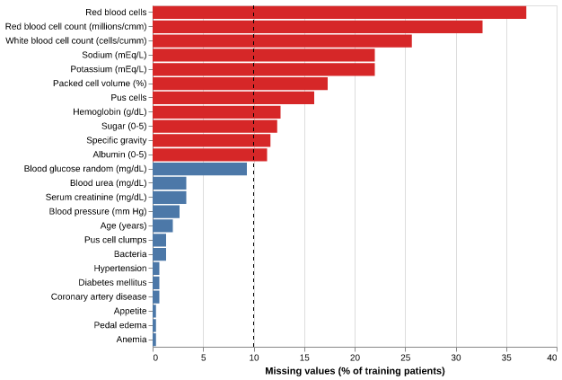

```python
pct_missing = train_df.drop(columns="class").isna().mean()
keep = pct_missing[pct_missing <= 0.1].index.tolist()

missing_df = (
    pct_missing.mul(100).rename("pct_missing")
    .rename_axis("feature").reset_index()
    .assign(feature=lambda d: d["feature"].map(labels))
)
bars = alt.Chart(missing_df).mark_bar().encode(
    x=alt.X("pct_missing:Q", title="Missing values (% of training patients)"),
    y=alt.Y("feature:N", sort="-x", title=None),
    color=alt.condition(
        alt.datum.pct_missing > 10, alt.value("#d62728"), alt.value("#4c78a8")
    ),
)
cutoff = alt.Chart(pd.DataFrame({"x": [10]})).mark_rule(strokeDash=[4, 4]).encode(x="x:Q")
(bars + cutoff).properties(width=450, height=380)
```

**Figure 1.** Percentage of missing values for each feature in the training set. Features past the dashed line (over 10% missing, in red) were dropped.

Next, we ranked the remaining features by how strongly they relate to CKD. We calculated the Pearson correlation between each feature and the diagnosis using every training patient with a value for that feature (Table 1). Hypertension (r = 0.60) and diabetes mellitus (r = 0.55) were the strongest, followed by random blood glucose (r = 0.41), appetite (r = 0.39) and blood urea (r = 0.39).

```python
to_number = {"yes": 1, "no": 0, "abnormal": 1, "normal": 0,
             "present": 1, "notpresent": 0, "poor": 1, "good": 0}
X_train = train_df[keep].replace(to_number).apply(pd.to_numeric)
y_train = (train_df["class"] == "ckd").astype(int)

strength = X_train.corrwith(y_train).sort_values(key=abs, ascending=False)

(
    strength.round(2)
    .rename("Correlation with CKD (r)")
    .rename(index=labels)
    .rename_axis("Feature")
    .to_frame()
)
```

| Feature | Correlation with CKD (r) |
| --- | --- |
| Hypertension | 0.60 |
| Diabetes mellitus | 0.55 |
| Blood glucose random (mg/dL) | 0.41 |
| Appetite | 0.39 |
| Blood urea (mg/dL) | 0.39 |
| Pedal edema | 0.37 |
| Serum creatinine (mg/dL) | 0.35 |
| Anemia | 0.31 |
| Blood pressure (mm Hg) | 0.28 |
| Pus cell clumps | 0.27 |
| Coronary artery disease | 0.25 |
| Age (years) | 0.23 |
| Bacteria | 0.18 |

**Table 1.** Pearson correlation between each kept feature and CKD diagnosis in the training set, strongest first.

We examined the correlations between features to avoid selecting features that carry the same information (Figure 2). Working down the ranking in Table 1, we added a feature only if it did not correlate with any already selected feature more strongly than 0.7 (in absolute value). None of the top-ranked features exceeded this threshold. The four selected features are therefore hypertension, diabetes mellitus, random blood glucose and appetite.

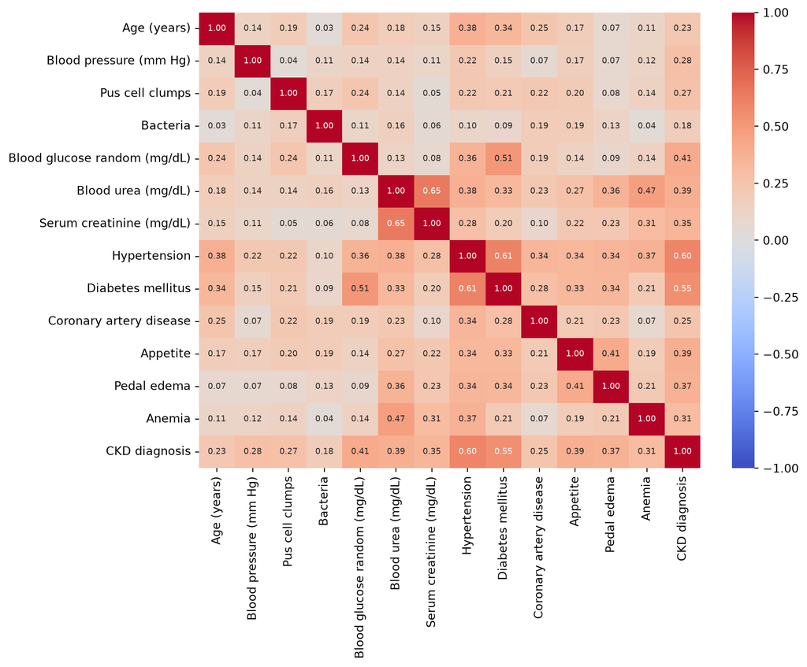

```python
corr = (
    X_train.assign(ckd=y_train).corr()
    .rename(index=labels | {"ckd": "CKD diagnosis"},
            columns=labels | {"ckd": "CKD diagnosis"})
)
plt.figure(figsize=(10, 8))
sns.heatmap(corr, annot=True, fmt=".2f", cmap="coolwarm", vmin=-1, vmax=1,
            annot_kws={"size": 7})
plt.tight_layout()
plt.show()
```

**Figure 2.** Pearson correlations between the 13 kept features and CKD diagnosis in the training set. Red indicates a positive correlation and blue a negative one.

```python
selected = []
for feature in strength.index:
    if all(abs(X_train[feature].corr(X_train[c])) < 0.7 for c in selected):
        selected.append(feature)
    if len(selected) == 4:
        break

Path("../data/processed").mkdir(parents=True, exist_ok=True)
cols = selected + ["class"]
train_df[cols].to_csv("../data/processed/ckd_train.csv", index=False)
test_df[cols].to_csv("../data/processed/ckd_test.csv", index=False)
```

The training and test sets using only the four selected features and the diagnosis were saved to `data/processed/` for model fitting.

### Preprocessing

We coded the diagnosis as 1 for CKD and 0 for not CKD. The three features with two categories (hypertension, diabetes mellitus and appetite) were imputed with their most frequent value and then one-hot encoded into a single binary column each. The one numeric feature, random blood glucose, was imputed with its median and then standardized. All imputation and scaling steps are part of the model pipeline, so they are learned from the training data only.

```python
from sklearn.impute import SimpleImputer
from sklearn.preprocessing import StandardScaler
from sklearn.preprocessing import OneHotEncoder
from sklearn.pipeline import make_pipeline
from sklearn.compose import make_column_transformer

train_df = pd.read_csv("../data/processed/ckd_train.csv")
X_train = train_df.drop(columns='class')
y_train = train_df['class'].map({"ckd": 1, "notckd": 0})

test_df = pd.read_csv("../data/processed/ckd_test.csv")
X_test = test_df.drop(columns='class')
y_test = test_df['class'].map({"ckd": 1, "notckd": 0})
```

```python
numeric_features = ['bgr']
binary_features = ['htn', 'dm', 'appet']

binary_imputer = SimpleImputer(strategy="most_frequent")
one_hot_encoder = OneHotEncoder(drop="if_binary", handle_unknown="ignore", sparse_output=False)
binary_transformer = make_pipeline(
    binary_imputer,
    one_hot_encoder
)

num_imputer = SimpleImputer(strategy="median")
scaler = StandardScaler()
numeric_transformer = make_pipeline(
    num_imputer,
    scaler
)

preprocessor = make_column_transformer(
    (binary_transformer, binary_features),
    (numeric_transformer, numeric_features)
)
```

### Model and hyperparameter tuning

We used a logistic regression classifier, which predicts the probability that a patient has CKD. To choose the regularization strength C, we ran 5-fold cross-validation on the training set over 17 values of C between 0.0001 and 10,000. We used the F2 score as the metric. The F2 score combines precision and recall but weights recall more heavily, because missing a patient with CKD is more harmful than a false alarm.

```python
from sklearn.linear_model import LogisticRegression
from sklearn.model_selection import GridSearchCV, cross_val_predict, FixedThresholdClassifier
from sklearn.metrics import fbeta_score, make_scorer, classification_report, precision_recall_curve, confusion_matrix
import numpy as np

lr = LogisticRegression()
lr_pipe = make_pipeline(preprocessor, lr)

param_grid = {
    'logisticregression__C': np.logspace(-4, 4, 17)
}

grid_search = GridSearchCV(
    estimator=lr_pipe,
    param_grid=param_grid,
    n_jobs=1,
    cv=5,
    scoring=make_scorer(fbeta_score, beta=2),
    return_train_score=True)

grid_search.fit(X_train, y_train)
best_C = grid_search.best_params_['logisticregression__C']
```

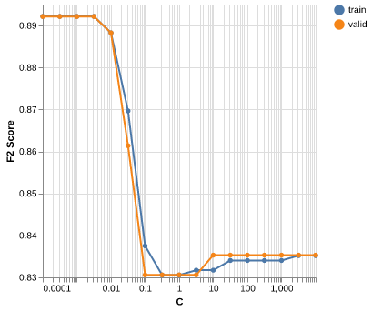

```python
def plot_train_cv(param_vals, train_scores, val_scores, xlabel, ylabel="F2 Score"):
    df = pd.DataFrame({
        "param": list(param_vals) * 2,
        "score": list(train_scores) + list(val_scores),
        "split": ["train"] * len(param_vals) + ["valid"] * len(param_vals),
    })

    return alt.Chart(df).mark_line(point=True).encode(
        x=alt.X("param:Q", scale=alt.Scale(type="log"), title=xlabel),
        y=alt.Y("score:Q", scale=alt.Scale(zero=False), title=ylabel),
        color=alt.Color("split:N", title=None),
        tooltip=["param", "split", alt.Tooltip("score:Q", format=".3f")],
    )

cv_results = grid_search.cv_results_
plot_train_cv(
    cv_results['param_logisticregression__C'],
    cv_results['mean_train_score'],
    cv_results['mean_test_score'],
    xlabel='C'
)
```

**Figure 3.** Mean F2 score on the training folds and validation folds of 5-fold cross-validation, for each value of the regularization strength C.

```python
lr_pipe.set_params(logisticregression__C=0.01)
lr_pipe.fit(X_train, y_train)
n_pred_ckd_small_C = int(lr_pipe.predict(X_train).sum())
```

The highest cross-validation F2 score was reached at a very small value of C, as shown in Figure 3. However, such a small C restricts the model so strongly that it cannot use any of the features. It then relies only on its intercept and predicts the majority class, CKD, for almost every patient. With C = 0.01, for example, the model predicted CKD for 299 of the 300 training patients. To avoid this problem, we set C to 1 instead.

### Decision threshold

```python
## Determine threshold that achieves at least 95% recall
lr_pipe.set_params(logisticregression__C=1)

# out-of-fold probability of CKD for each training row
proba = cross_val_predict(lr_pipe, X_train, y_train, cv=5, method="predict_proba")[:, 1]

precision, recall, thresholds = precision_recall_curve(y_train, proba)

# highest threshold that still achieves recall >= 0.95
target = 0.95
idx = np.where(recall[:-1] >= target)[0][-1]
threshold = thresholds[idx]
```

By default, logistic regression predicts CKD when the predicted probability is at least 0.5. Because false negatives are costly, we lowered this decision threshold. Using 5-fold cross-validation on the training set, we obtained an out-of-fold predicted probability of CKD for every training patient. We then chose the highest threshold that still achieved a recall of at least 0.95. This threshold was 0.29, with a cross-validation recall of 0.95 and precision of 0.76 (Figure 4).

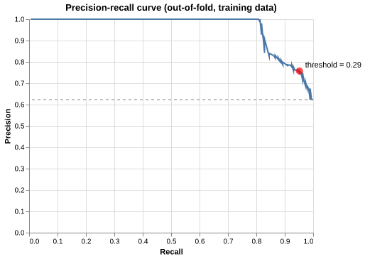

```python
## Precision-Recall Curve with identified threshold
pr_df = pd.DataFrame({
    "recall": recall[:-1],
    "precision": precision[:-1],
    "threshold": thresholds,
})

curve = alt.Chart(pr_df).mark_line().encode(
    x=alt.X("recall:Q", title="Recall", scale=alt.Scale(domain=[0, 1])),
    y=alt.Y("precision:Q", title="Precision", scale=alt.Scale(domain=[0, 1])),
    tooltip=[alt.Tooltip(c, format=".3f") for c in ["threshold", "recall", "precision"]],
)

chosen = alt.Chart(pd.DataFrame({
    "recall": [recall[idx]],
    "precision": [precision[idx]],
    "label": [f"threshold = {threshold:.2f}"],
})).mark_point(size=100, filled=True, color="red").encode(
    x="recall:Q", y="precision:Q"
)

label = chosen.mark_text(align="left", dx=8, dy=-8).encode(text="label:N")

baseline = alt.Chart(pd.DataFrame({"y": [y_train.mean()]})).mark_rule(
    strokeDash=[4, 4], color="gray"
).encode(y="y:Q")

(curve + baseline + chosen + label).properties(
    title="Precision-recall curve (out-of-fold, training data)",
    width=400, height=300,
)
```

**Figure 4.** Precision-recall curve from out-of-fold predictions on the training set. The red point marks the chosen decision threshold, and the dashed grey line shows the proportion of training patients with CKD.

Finally, we fit the logistic regression model with C = 1 on the full training set, using the chosen decision threshold of 0.29.

```python
final_model = FixedThresholdClassifier(lr_pipe, threshold=0.29)
final_model.fit(X_train, y_train);
```

## Results

```python
from sklearn.metrics import (
    accuracy_score, precision_score, recall_score, f1_score, fbeta_score,
    confusion_matrix, ConfusionMatrixDisplay,
)

y_pred = final_model.predict(X_test)

acc = accuracy_score(y_test, y_pred)
prec = precision_score(y_test, y_pred)
rec = recall_score(y_test, y_pred)
f1 = f1_score(y_test, y_pred)
f2 = fbeta_score(y_test, y_pred, beta=2)

# rows = true class, columns = predicted class; CKD (1) first
cm = confusion_matrix(y_test, y_pred, labels=[1, 0])
tp, fn, fp, tn = (int(v) for v in cm.ravel())
n_test = len(y_test)
n_ckd_test = tp + fn
n_notckd_test = fp + tn

pd.DataFrame(
    {
        "Accuracy": [acc],
        "Precision": [prec],
        "Recall": [rec],
        "F1 score": [f1],
        "F2 score": [f2],
    },
    index=["Test set"],
).round(2)
```

|  | Accuracy | Precision | Recall | F1 score | F2 score |
| --- | --- | --- | --- | --- | --- |
| Test set | 0.74 | 0.73 | 0.92 | 0.82 | 0.88 |

**Table 2.** Performance of the final model on the test set, with CKD as the positive class.

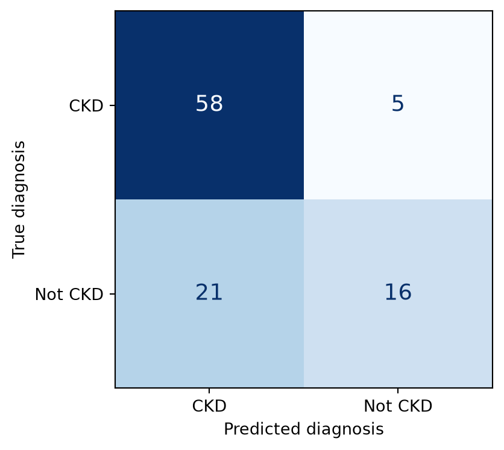

```python
fig, ax = plt.subplots(figsize=(5, 4))
ConfusionMatrixDisplay(cm, display_labels=["CKD", "Not CKD"]).plot(
    ax=ax, cmap="Blues", colorbar=False, text_kw={"fontsize": 14}
)
ax.set_xlabel("Predicted diagnosis")
ax.set_ylabel("True diagnosis")
plt.tight_layout()
plt.show()
```

**Figure 5.** Confusion matrix of the final model’s predictions on the test set. Rows show the true diagnosis and columns show the diagnosis predicted by the model.

We evaluated the final model on the 100 patients in the test set, which were not used at any point during feature selection or model training. The model achieved a recall of 0.92, a precision of 0.73, an F1 score of 0.82, an F2 score of 0.88, and an overall accuracy of 0.74 (Table 2). Of the 63 test patients with CKD, the model correctly identified 58 and missed 5 (Figure 5). These false negatives are the most harmful type of error in our context, because these patients could miss the follow-up testing and treatment they need. The model was much less accurate for patients without CKD: it predicted CKD for 21 of the 37 patients without the disease (false positives), and correctly classified only 16 of them. This trade-off is expected, because we chose a low decision threshold to catch as many CKD patients as possible.

## Discussion

We developed a model that is able to predict chronic kidney disease in patients with reasonable performance. The model uses information on whether a patient has hypertension, diabetes mellitus, their appetite and their blood glucose random test values. Our model was specifically tuned to minimize false negative predictions since these are the most dangerous outcome in a clinical setting that could lead to avoidable adverse health outcomes for patients.

An additional check that would improve model reliability would be to compare the signs and magnitudes of the model coefficients with clinical expectations for the relationship between those features and chronic kidney disease. In a clinical setting, it could also be beneficial to output the model probabilities to give clinicians an estimate of how confident the model is for each prediction.

## References

GBD Chronic Kidney Disease Collaboration. 2020. “Global, Regional, and National Burden of Chronic Kidney Disease, 1990–2017: A Systematic Analysis for the Global Burden of Disease Study 2017.” *The Lancet* 395 (10225): 709–733. https://doi.org/10.1016/S0140-6736(20)30045-3.

Kovesdy, Csaba P. 2022. “Epidemiology of Chronic Kidney Disease: An Update 2022.” *Kidney International Supplements* 12 (1): 7–11. https://doi.org/10.1016/j.kisu.2021.11.003.

Qin, Jiongming, Lin Chen, Yuhua Liu, Chuanjun Liu, Changhao Feng, and Bin Chen. 2020. “A Machine Learning Methodology for Diagnosing Chronic Kidney Disease.” *IEEE Access* 8: 20991–21002. https://doi.org/10.1109/ACCESS.2019.2963053.

Rubini, L., P. Soundarapandian, and P. Eswaran. 2015. “Chronic Kidney Disease.” UCI Machine Learning Repository. https://doi.org/10.24432/C5G020.